# 4 Statistical Frameworks Study Guide (and other notes?)

EA30 2023 Students and Marc

2023-03-27

# Using R to Create R Study Guide

## Class Assignment

The study guide development will go for five weeks, so everyone can have a change to look at each of the for frameworks and then one session to integrate everything into one document. See Sakai to see your group assignment.

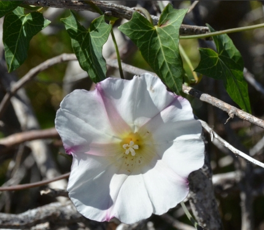

Calystegia purpurata is a species of morning glory known by the common name Pacific false bindweed. It is endemic to California, where it grows in the seaside scrub of the coastline and the chaparral of the coastal and inland valleys.

```r
knitr::include_graphics("https://github.com/marclos/beginnersluck/raw/master/Stats/EA30_Study_Guide/Calystegic_purpurata.jpg")
```

## Developing Content

Each week, I intend to dedicate 30-45 minutes to develop content.

We’ll start with creating an example. But as we do, we want to be answering these following questions:

- What questions can be answered with the method?
- Are their limitations to the method?
- What are the assumptions?
- How can the assumptions be tested?
- Create R code to explore some examples
- Put comments (using # symbol) after R code to help others understand what’s going on.
- Create a “list of R functions” in Appendix 1
- Create a study guide “test”, evaluation questions, Appendix 2.

The example should include data to be analyzed – either imported or created in R, then the R codes to analyze the results and then a discussion about how to interpret the data.

After each week, please upload the version you have edited and I will harmonize the 4 groups work into one document for the following week.

# Getting Started with R

## R and Rstudio

### What is R?

R is a language and environment for statistical computing and graphics. R provides a wide variety of statistical (linear and nonlinear modelling, classical statistical tests, time-series analysis, classification, clustering, etc.) and graphical techniques, and is highly extensible.

One of R’s strengths is the ease with which well-designed publication-quality plots can be produced, including mathematical symbols and formula where needed.

### Getting started in R

TBD

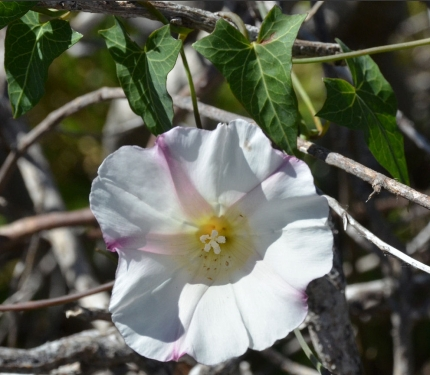

Calystegia purpurata is a species of morning glory known by the common name Pacific false bindweed. It is endemic to California, where it grows in the seaside scrub of the coastline and the chaparral of the coastal and inland valleys.

```r
knitr::include_graphics("https://github.com/marclos/beginnersluck/raw/master/Stats/EA30_Study_Guide/Calystegic_purpurata.jpg")
```

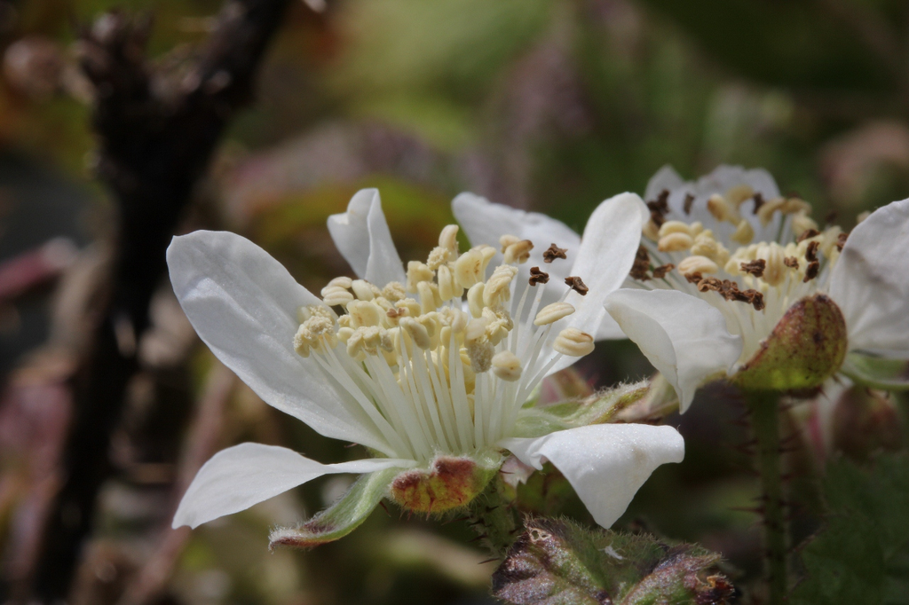

A deciduous climbing or trailing evergreen shrub. Native blackberry is not aggressive like it’s Himalayan cousin. The berries are edible and tasty. Flowers host beneficial insects. Tolerates salt spray in shoreline and bluff plantings.

```r
knitr::include_graphics("https://github.com/marclos/beginnersluck/raw/master/Stats/EA30_Study_Guide/Rubus_ursinus.jpg")
```

```r
summary(cars) # extract summary statistics from built-in cars dataset.
```

```
##      speed           dist
##  Min.   : 4.0   Min.   :  2.00
##  1st Qu.:12.0   1st Qu.: 26.00
##  Median :15.0   Median : 36.00
##  Mean   :15.4   Mean   : 42.98
##  3rd Qu.:19.0   3rd Qu.: 56.00
##  Max.   :25.0   Max.   :120.00
```

I added the comment line to help the reader remember what’s happening. These comments are useful to help everyone see the intentions of the author.

## Updated Template to Create Study Guide

I created this document to give you a “head-start” in creating the study guide with a format that everyone can use. By using Rstudio, you will have the capacity to create an integrated approach that merges R commands and outputs and text.

I have defined the output as a word document to start with – but we can create a pdf or html output if we decide that is better. But by putting into Word, we can use Word to spot typos easier!

There are ways to share these documents via github.com – but frankly, it works great if the class is smaller, e.g. 10-12. So, we’ll use an assortment of sakai upload tools – not ideal, but I’ll make it work!

## Editing the Guide

Please use Rcode chunks and text as you edit. Be sure to export as a .Rmd file!

## Run the Template

Make sure the template you downloaded runs! Nothing is more frustrating (hyperbole?) than trying to troubleshoot someone else’s code!

# Variables and Statistics

## Defining Variable Types

### Continuous vs. Count vs. Categorical

MLH: Describe…these…

We can interrogate the data if we are unsure using the str() function, which coerces the data.frame into a format to evaluate the structure.

```r
str(pressure)
```

```
## 'data.frame':    19 obs. of  2 variables:
##  $ temperature: num  0 20 40 60 80 100 120 140 160 180 ...
##  $ pressure   : num  0.0002 0.0012 0.006 0.03 0.09 0.27 0.75 1.85 4.2 8.8 ...
```

In this case, we find that the object “pressure” is a data.frame that is composed of two variables – and both seem to be numeric.

## Example of Plastic Data…

### Dependent vs. Independent Data

In some cases, we can manipulate an environmental setting or characteristic and test the impact on another characteristics. We generally call the one that we can manipulate as the independent variable and the measured response as the dependent variable.

Graphically, we often see the independent variable as the x-axis. The independent call might also be referred to as the predictor variable. The response as the dependent (or response) variable.

In our titles, we often refer to the dependent first – “Response as a Function of X” or “Water Temperature vs. Air Temperature”

NOTE: Spatial Data and Time Series data have special concerns. For example, when we take a sample from a creek every day – the creek water might be different, but the processes that contribute to its characteristics are quite similar, compared to water from another creek. Thus, we might note that the samples taken are autocorrelated.

“Auto-correlation”…, see below…Autocorrelation Section

#### Graphical Example of Independent and Dependent Variables

Plotting data as a data.frame is pretty straightforward, but there are two main syntax methods.

1. Define x and y in the plot function:

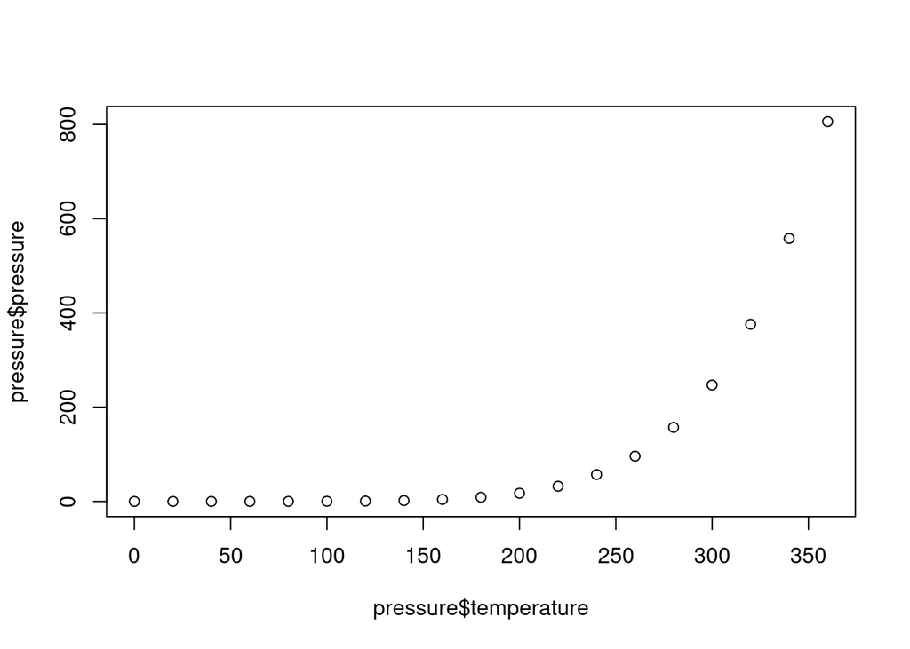

```r
plot(x=pressure$temperature, y=pressure$pressure) # Notice the data.frame is explicitly referenced and then the variable of interest after the dollar symbol.
```

2. Alternatively, you can use the formula syntax:

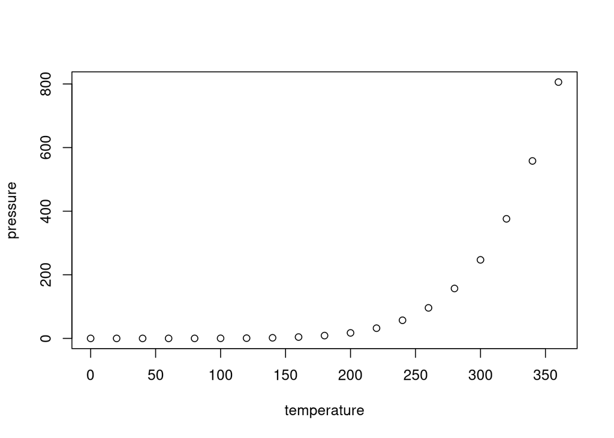

```r
plot(pressure ~ temperature, data=pressure) # in this case the data.frame is called by the "data=" argument.
```

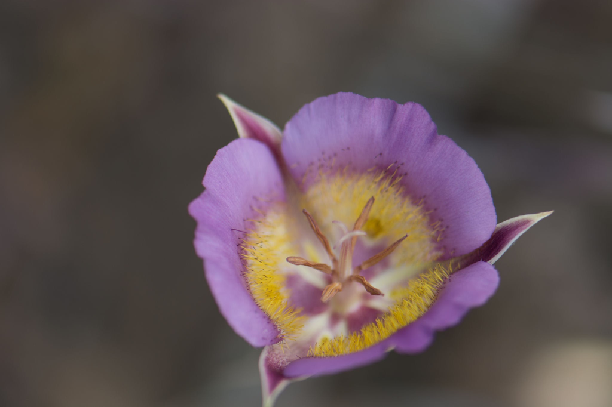

Calochortus plummerae is a perennial herb (bulb) that is native to California, and endemic (limited) to California.

```r
knitr::include_graphics("https://github.com/marclos/beginnersluck/raw/master/Stats/EA30_Study_Guide/Calochortus_plummerae.jpg")
```

https://github.com/marclos/beginnersluck/raw/master/Stats/EA30_Study_Guide/Calochortus_plummerae.jpg

# Four Frameworks

## Linear Regression

MLH: What is linear Regression

Calystegia: Linear regression is one of the most commonly used predictive analyses. It answers the question:Does a set of predictor variables do a good job in predicting an outcome (dependent) variable? link to definition – see my example in Rmd file. It’s used to predict the value of a variable (the dependent variable) based on an input value (the independent/predictor variable), Variable Types Section

MLH: What kinds of questions is the linear regression best suited for?

Calystegia: It’s used to answer questions about the relationship between two variables or the strength of a cause/effect relationship. It also is helpful if you have multiple independent variables because you can find out which variable(s) best predicts the dependent variable. Let’s define the difference between correlation and causation…<>

MLH: What are the “under the hood methods” used to analyze the data? Is this supported by theory? Is there any of the theory that’s useful for users?

Calystegia: Linear regression is best visualized on a scatterplot. Linear regression will fit a straight line on the plot (a line of best fit) and will measure the distance between the actual values and the predicted values on the line to determine how well the line predicts the values.

## Linear Regression Examples

### Example #1

We know surface water temperatures depend on the sunlight. But what about surface air temperature?

Is water and air temperature correlated? (whats the difference between correlation and regression?)

Calystegia: Correlation doesn’t say anything about cause and effect while regression does. Regression expresses the cause and effect relationship between variables in the form of an equation.

What’s the rcode doing here?

```r
water = c(50, 52, 65, 67, 68, 78, 54, 63, 57, 58)
air = c(60, 75, 85, 86, 73, 76, 78, 92, 59,62)
lm(formula = water ~ air)
```

```
##
## Call:
## lm(formula = water ~ air)
##
## Coefficients:
## (Intercept)          air
##     36.3333       0.3333
```

making a graph…

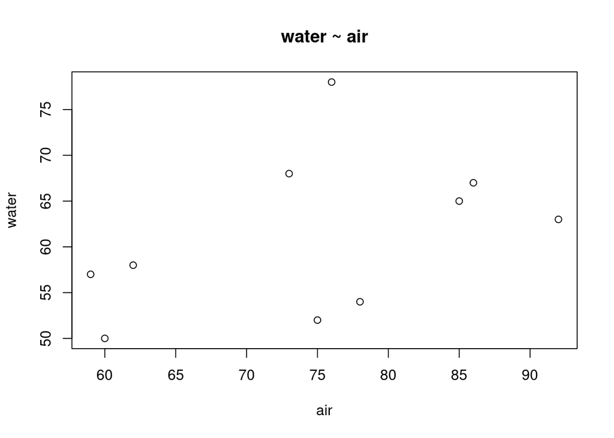

```r
plot(x=air, y=water, main="water ~ air")
```

Describe the results…

### Example #2: SRP and HABs

Following HABs and SRP as a predictor…

MLH: Describe why these data can be analyzed using regression

Calystegia: These data can be analyzed using a linear regression (specifically a simple linear regression) because they are both quantitative forms of data and we are trying to determine if they have a cause and effect relationship, between an independent and dependent variable.

##### Define Data:

MLH: What’s the rcode doing here?

```r
SRP <- c(.02, .03, 0.4, 0.04, .05, 0.033, 1.4)
cyano<- c(22, 34, 23, 22, 23, 2, 122)
```

#### Create Linear Model using lm() function

The linear model coerces the data into a new object using a least squares method to calculate the slope and intercept (and other statistical date.)

MLH: What’s the rcode doing here

Calochortus: The rcode is using the lm [linear regression model function] to create a linear model using a least squares approach.

Using the model allows us to create a best fit line (with the slope and intercept) and illustrate the relationship between between SRP and HABs.

```r
HAB.lm = lm(cyano ~ SRP)
HAB.lm
```

```
##
## Call:
## lm(formula = cyano ~ SRP)
##
## Coefficients:
## (Intercept)          SRP
##       15.03        72.37
```

#### Model Summary (Results)

Let’s look at the model results with summary()

```r
summary(HAB.lm)
```

```
##
## Call:
## lm(formula = cyano ~ SRP)
##
## Residuals:
##       1       2       3       4       5       6       7
##   5.523  16.799 -20.979   4.076   4.352 -15.418   5.647
##
## Coefficients:
##             Estimate Std. Error t value Pr(>|t|)
## (Intercept)   15.029      6.398   2.349  0.06563 .
## SRP           72.374     11.608   6.235  0.00155 **
## ---
## Signif. codes:  0 '***' 0.001 '**' 0.01 '*' 0.05 '.' 0.1 ' ' 1
##
## Residual standard error: 14.55 on 5 degrees of freedom
## Multiple R-squared:  0.886,  Adjusted R-squared:  0.8632
## F-statistic: 38.87 on 1 and 5 DF,  p-value: 0.001554
```

MLH: What’s the rcode doing here?

MLH: Describe results…

Is this clear?

MLH: What’s the rcode doing here?

MLH: maybe make better x and y labels? – brainstorm with marc to come up with ideas…write out as psudocode…

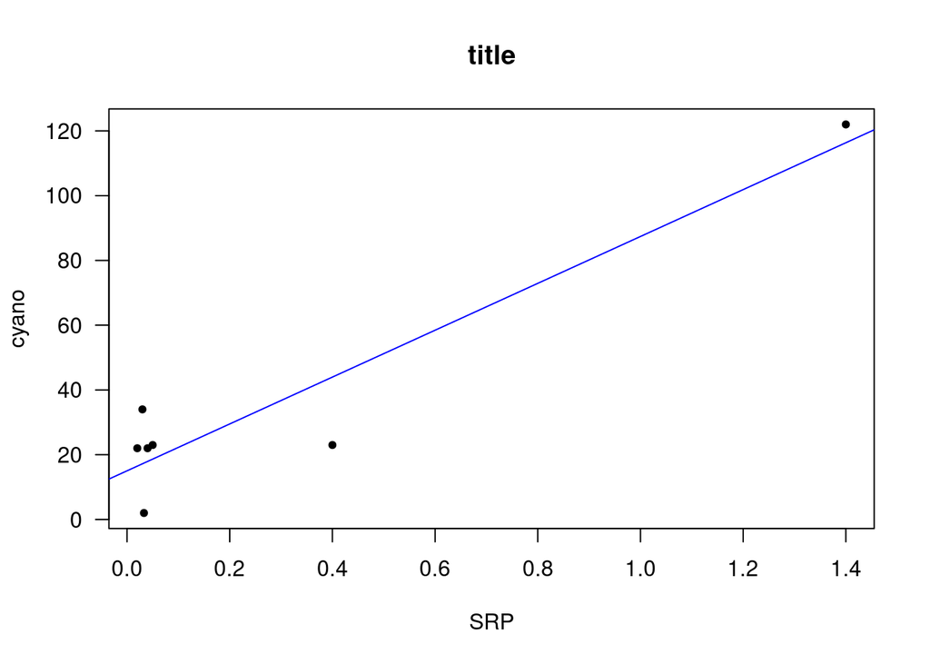

```r
plot(cyano ~ SRP, las=1, main="title", pch=20)
abline(HAB.lm, col="blue")
```

#### Model Interpretation (Discussion)

please add text here…what is the difference between reporting results and interpresting the results?

##### Linear Regression Assumptions

Let’s look at a default plot of model…why plot of model? different than plot of data?

MLH: What do these mean?

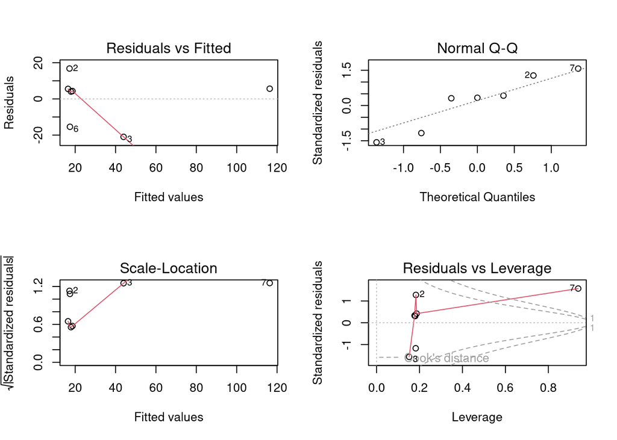

```r
par(mfrow=c(2,2))
plot(HAB.lm)## mfrow allows you to creat a number of plot in one graph, you have to provide a vector of the number of rows and number of columns
```

```r
##the par() function creates multiple plots at one
##Allows you to plot multiple points, the mfrow function allows you to split the screen into panels (basically split your screen)
## plot(HAB.lm) is plot diagnostics
```

Describe each of the panels…

```r
Anscombe = as.data.frame(
  matrix(c(
    1, 10, 10, 10, 8, 8.04, 9.14, 7.46, 6.58,
    2, 8, 8, 8, 8, 6.95, 8.14, 6.77, 5.76,
    3, 13, 13, 13, 8, 7.58, 8.74, 12.74, 7.71,
    4,  9, 9, 9, 8, 8.81, 8.77, 7.11, 8.84,
    5, 11, 11, 11, 8, 8.33, 9.26, 7.81, 8.47,
    6, 14, 14, 14, 8, 9.96, 8.10, 8.84, 7.04,
    7,  6, 6, 6, 8, 7.24, 6.13, 6.08, 5.25,
    8,  4, 4, 4, 19, 4.26, 3.10, 5.39, 12.50,
    9, 12, 12, 12, 8, 10.84, 9.13, 8.15, 5.56,
    10, 7, 7, 7, 8, 4.82, 7.26, 6.42, 7.91,
    11, 5, 5, 5, 8, 5.68, 4.74, 5.73, 6.89),
    nrow=11,  byrow=TRUE))


names(Anscombe) = c("Obs.", "x1", "x2", "x3", "x4", "y1", "y2", "y3", "y4")
```

Anscombe

## Logistic Regression

MLH: What is this used for?

MLH: What are good questions for this?

### Example #1: Algae Concentration and Toxicity

Toxicity is a measure of toxity based on organism responses, often measured as LD50s, where 50% of the populations dies at a certain concentration.

Here we use the results of different concentrations of a toxin and the number of surviving Daphnia – a very common freshwater test organism.

MLH: Describe DATA…

```
## 'data.frame':    175 obs. of  2 variables:
##  $ Dose  : num  0 0 0 0 0 0 0 0 0 0 ...
##  $ Result: num  1 1 1 1 1 1 1 1 1 1 ...
```

Create a nice table of results…

MLH: what are ones and zeros?

```r
table(Results.df)
```

```
##      Result
## Dose   0  1
##   0    7 18
##   0.5  6 19
##   1   13 12
##   1.5 20  5
##   2   19  6
##   2.5 23  2
##   3   24  1
```

```r
# Results.df$Result <- as.factor(Results.df$Result)
Results.logit <- glm(Result ~ Dose, data = Results.df, family = "binomial")
```

### Results

MLH: What do these results mean?

```r
summary(Results.logit)
```

```
##
## Call:
## glm(formula = Result ~ Dose, family = "binomial", data = Results.df)
##
## Deviance Residuals:
##     Min       1Q   Median       3Q      Max
## -1.7688  -0.8461  -0.4389   0.9334   2.4753
##
## Coefficients:
##             Estimate Std. Error z value Pr(>|z|)
## (Intercept)   1.3296     0.3275    4.06 4.90e-05 ***
## Dose         -1.4485     0.2303   -6.29 3.18e-10 ***
## ---
## Signif. codes:  0 '***' 0.001 '**' 0.01 '*' 0.05 '.' 0.1 ' ' 1
##
## (Dispersion parameter for binomial family taken to be 1)
##
##     Null deviance: 228.70  on 174  degrees of freedom
## Residual deviance: 171.04  on 173  degrees of freedom
## AIC: 175.04
##
## Number of Fisher Scoring iterations: 4
```

#### Interpretation (Discussion)

```r
# define new data frame that contains predictor variable
newdata <- data.frame(Dose=seq(min(Results.df$Dose), max(Results.df$Dose),len=100))

# use fitted model to predict values of vs
newdata$Result = predict(Results.logit, newdata, type="response")
```

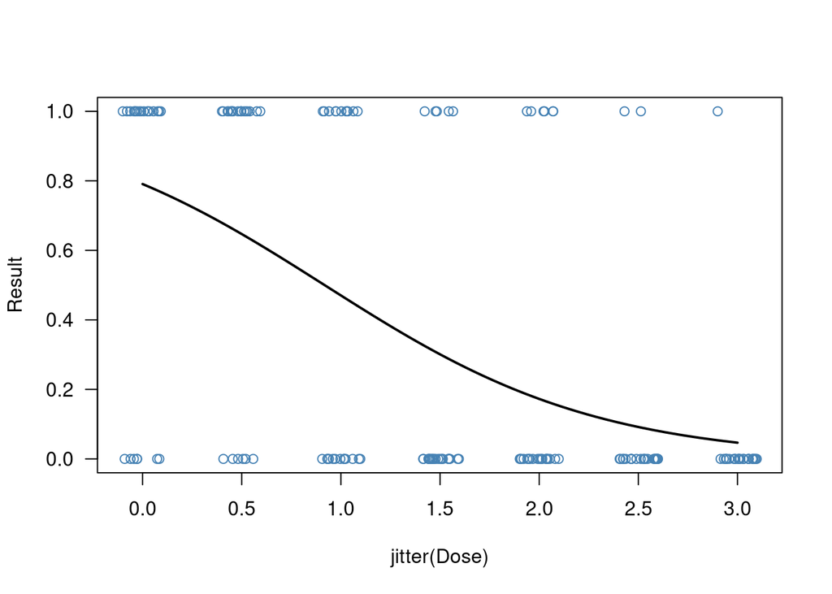

```r
# plot logistic regression curve
plot(Result ~ jitter(Dose), data=Results.df, col="steelblue", las=1)
lines(Result ~ Dose, newdata, lwd=2)
```

LD50 = dose at which Pr(dead | dose) = 0.5.

MLH: found this formula online… don’t know if it works…

$$ln(\frac{\frac{1}{2}}{1-\frac{1}{2}}) =
\beta_1 + \beta_0 (LD_{50})$$

$$0 = \beta_1 + \beta_0
(LD_{50})$$
$$\widehat{{LD_{50}} =
\frac{- \beta_0}{\beta_1}}$$

Calculating Standard Error… MLH: Haven’t tried this yet

### Example #3

Will a person win an election?

MLH: What are good questions for this? Possible questions may include - will an indiviudal win the election? predictor = number of votes; response = win or loss

# ANOVA

What is a one-way ANOVA?

What is the ANOVA used for?

## Example 1: Simulated HAB Data

Here are the (fake) data:

Controls have a mean of 35 (and Standard Deviation of 8), Low Density treatment has a mean of 33 (SD = 8) and high density mean of 31 (SD=8)

```
##   [1]  1  2  3  4  5  6  7  8  9 10 11 12 13 14 15  1  2  3  4  5  6  7  8  9 10
##  [26] 11 12 13 14 15  1  2  3  4  5  6  7  8  9 10 11 12 13 14 15  1  2  3  4  5
##  [51]  6  7  8  9 10 11 12 13 14 15  1  2  3  4  5  6  7  8  9 10 11 12 13 14 15
##  [76]  1  2  3  4  5  6  7  8  9 10 11 12 13 14 15  1  2  3  4  5  6  7  8  9 10
## [101] 11 12 13 14 15  1  2  3  4  5  6  7  8  9 10 11 12 13 14 15  1  2  3  4  5
## [126]  6  7  8  9 10 11 12 13 14 15  1  2  3  4  5  6  7  8  9 10 11 12 13 14 15
```

```
##   [1] "Control" "Control" "Control" "Control" "Control" "Control" "Control"
##   [8] "Control" "Control" "Control" "Control" "Control" "Control" "Control"
##  [15] "Control" "Control" "Control" "Control" "Control" "Control" "Control"
##  [22] "Control" "Control" "Control" "Control" "Control" "Control" "Control"
##  [29] "Control" "Control" "Control" "Control" "Control" "Control" "Control"
##  [36] "Control" "Control" "Control" "Control" "Control" "Control" "Control"
##  [43] "Control" "Control" "Control" "Control" "Control" "Control" "Control"
##  [50] "Control" "LD"      "LD"      "LD"      "LD"      "LD"      "LD"
##  [57] "LD"      "LD"      "LD"      "LD"      "LD"      "LD"      "LD"
##  [64] "LD"      "LD"      "LD"      "LD"      "LD"      "LD"      "LD"
##  [71] "LD"      "LD"      "LD"      "LD"      "LD"      "LD"      "LD"
##  [78] "LD"      "LD"      "LD"      "LD"      "LD"      "LD"      "LD"
##  [85] "LD"      "LD"      "LD"      "LD"      "LD"      "LD"      "LD"
##  [92] "LD"      "LD"      "LD"      "LD"      "LD"      "LD"      "LD"
##  [99] "LD"      "LD"      "HD"      "HD"      "HD"      "HD"      "HD"
## [106] "HD"      "HD"      "HD"      "HD"      "HD"      "HD"      "HD"
## [113] "HD"      "HD"      "HD"      "HD"      "HD"      "HD"      "HD"
## [120] "HD"      "HD"      "HD"      "HD"      "HD"      "HD"      "HD"
## [127] "HD"      "HD"      "HD"      "HD"      "HD"      "HD"      "HD"
## [134] "HD"      "HD"      "HD"      "HD"      "HD"      "HD"      "HD"
## [141] "HD"      "HD"      "HD"      "HD"      "HD"      "HD"      "HD"
## [148] "HD"      "HD"      "HD"
```

```
##  [1] 1 1 1 1 1 1 1 1 1 1
```

```
##   [1] 27.5 46.0 37.6 34.0 37.1 37.2 47.4 37.0 32.8 40.7 29.6 31.9 35.2 33.3 29.5
##  [16] 49.1 33.4 39.3 40.9 47.1 32.1 34.4 38.5 42.3 37.1 51.5 35.5 36.1 38.3 33.8
##  [31] 38.4 37.9 33.2 37.8 41.7 36.4 30.0 28.1 33.1 21.4 22.4 43.5 40.1 35.0 40.7
##  [46] 30.6 30.5 40.6 33.6 48.4 26.3 30.0 28.5 29.2 31.2 36.0 47.5 27.5 44.0 13.3
##  [61] 35.8 18.3 32.6 33.3 26.7 39.9 37.5 42.7 47.6 39.2 18.4 47.2 35.5 28.8 30.8
##  [76] 34.0 29.8 44.3 34.6 28.0 26.8 20.7 37.6 52.4 21.3 37.7 40.7 35.8 30.7 18.1
##  [91] 39.2 21.6 52.8 25.6 30.6 29.9 39.2 22.6 40.6 42.6 37.0 35.2 48.2 24.8 40.7
## [106] 42.1 31.5 28.8 23.4 43.3 23.6 25.7 14.2 39.6 37.8 33.9 16.1 38.2 21.1 26.2
## [121] 34.7 34.0 37.9 36.0 31.3 29.3 27.1 19.3 27.9 14.6 30.3 29.7 43.9 16.8 37.1
## [136] 29.6 30.4 30.5 28.0 25.3 31.9 20.4 36.3 29.8 26.5 31.8 37.2 42.2 21.4 32.1
```

### First six observations and histograms

```r
head(Mussel)
```

```
##   Mesocosm Treatment Day Results
## 1        1   Control   1    27.5
## 2        2   Control   1    46.0
## 3        3   Control   1    37.6
## 4        4   Control   1    34.0
## 5        5   Control   1    37.1
## 6        6   Control   1    37.2
```

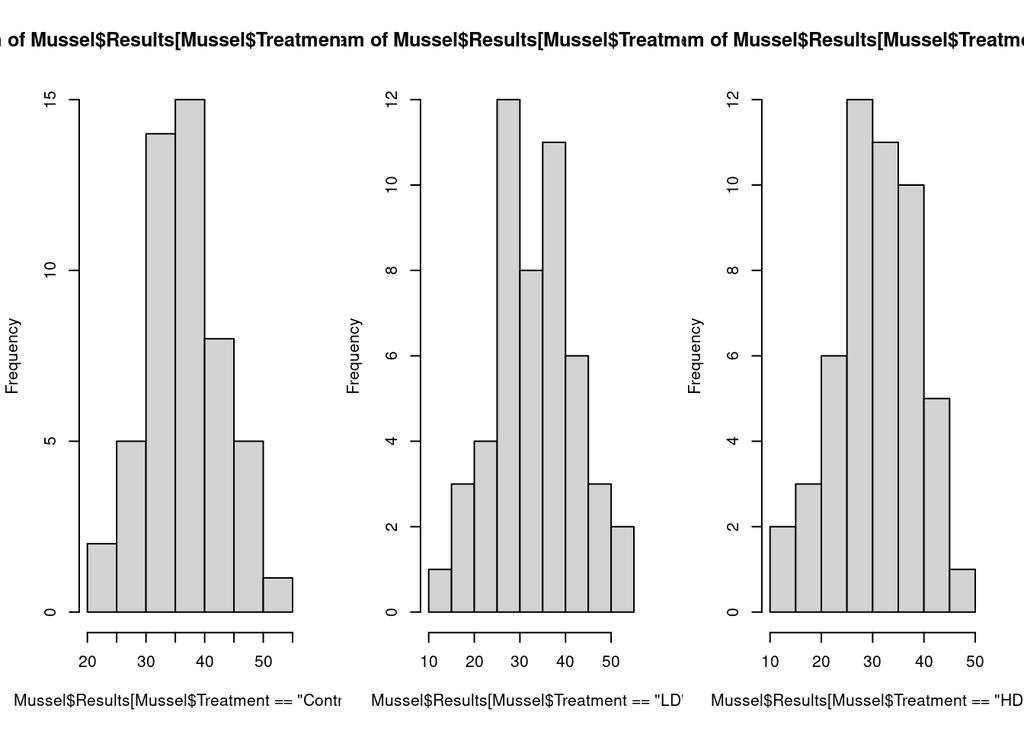

```r
par(mfrow=c(1,3))
hist(Mussel$Results[Mussel$Treatment=="Control"])
hist(Mussel$Results[Mussel$Treatment=="LD"])
hist(Mussel$Results[Mussel$Treatment=="HD"])
```

### Create AOV Object (Analysis of Variance) Using Least Squares Method

What are least squares?

```r
Mussel.aov <- aov(results ~ treatment, data=Mussel)
```

### Results

```r
summary(Mussel.aov)
```

[output not shown]

### Exploring Chaning Parameters

MLH:Play with means or SD to see how it changes results

A lower standard deviation meant that the data were more clustered around the mean – MLH: this is doesn’t not tell the reader much… what about the summary, p value, ect?

#### Change Mean

MLH: add rcode and describe results

#### Change SD

MLH: add rcode and describe results

#### Change N

MLH: add rcode and describe results

### Some graphical Displays

Using a normal distribution, what do the data look like?

The data is symmetrically distributed with no skew.

MLH: What do these mean?

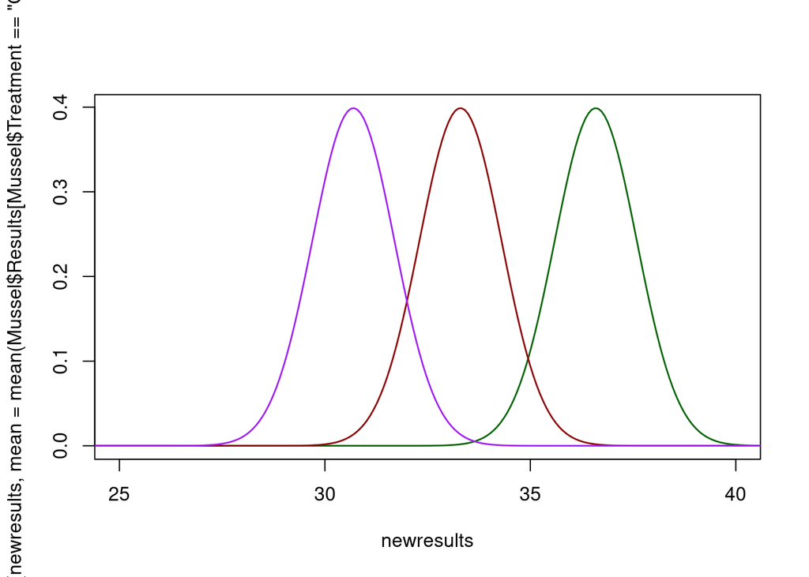

```r
newresults = seq(min(Mussel$Results), max(Mussel$Results), length=500)
plot(newresults, dnorm(newresults, mean=mean(Mussel$Results[Mussel$Treatment=="Control"])), ty="l", xlim=c(25,40), col="darkgreen", lwd=1.4)
lines(newresults, dnorm(newresults, mean=mean(Mussel$Results[Mussel$Treatment=="LD"])), ty="l", col="darkred", lwd=1.4)
lines(newresults, dnorm(newresults, mean=mean(Mussel$Results[Mussel$Treatment=="HD"])), ty="l", col="purple", lwd=1.4)
```

### Power Analaysis – ANOVA and Sample Size

Use this example: https://stats.oarc.ucla.edu/r/dae/one-way-anova-power-analysis/ and create an “environmental example” and translate the results for class

### Power Analaysis – ANOVA and Sample Size – Rubus

A power analysis helps determine an appropriate sample size. To do so, it requires 5 types of data: the number of groups, the between group variance, the within group variance, the alpha level, and the sample size/power.

The number of groups refers to the number of treatments/categories within an analysis of variants. It is often represented as “groups”. The between group variance refers to the difference between group, the within group variance refers to the difference within each individual group, the alpha level relates to the probability of rejecting the null hypothesis when it is true, and the power refers to the probability the test will determine a statistically significant when that difference exists.

Next steps after running the initial Power Anova Test include plotting the results and analyzing effect size.

The between group variance references Use this example: https://stats.oarc.ucla.edu/r/dae/one-way-anova-power-analysis/ and create an “environmental example” and translate the results for class

```r
groupmeans <- c(550, 598, 598, 646)
n <- c(seq(2,10,by=1),seq(12,20,by=2),seq(25,50,by=5))
groups = 4
              n = NA
    between.var = 1536
     within.var = 6400
      sig.level = 0.05
      power = .823
p <- power.anova.test(groups = length(groupmeans),
between.var = var(groupmeans), within.var = 6400,
power=0.823,sig.level=0.05,n=NULL)
p
```

```
##
##      Balanced one-way analysis of variance power calculation
##
##          groups = 4
##               n = 16.98893
##     between.var = 1536
##      within.var = 6400
##       sig.level = 0.05
##           power = 0.823
##
## NOTE: n is number in each group
```

##### Playing with N to see the impact on power:

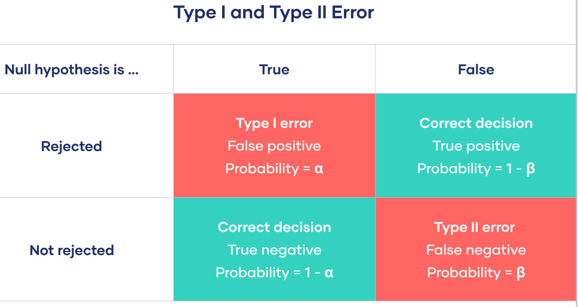

```r
knitr::include_graphics("https://github.com/marclos/beginnersluck/raw/master/Stats/EA30_Study_Guide/type-i-ii-error.jpg")
```

Let’s continue with 4 treatements – or groups.

```r
groupmeans <- c(550, 598, 598, 646)
between.var = var(groupmeans)
within.var = 6400
sig.level = 0.05

n <- c(seq(2,10,by=1),seq(12,20,by=2),seq(25,50,by=5))

# power = null
p <- power.anova.test(groups = length(groupmeans),
      between.var = var(groupmeans),
      within.var = 6400,
      n = n, power= NULL,
      sig.level=0.05)
p
```

```
##
##      Balanced one-way analysis of variance power calculation
##
##          groups = 4
##               n = 2, 3, 4, 5, 6, 7, 8, 9, 10, 12, 14, 16, 18, 20, 25, 30, 35, 40, 45, 50
##     between.var = 1536
##      within.var = 6400
##       sig.level = 0.05
##           power = 0.09067458, 0.14381195, 0.20139579, 0.26146007, 0.32241923, 0.38293139, 0.44190044, 0.49846996, 0.55200591, 0.64840471, 0.72949120, 0.79552098, 0.84785780, 0.88840023, 0.95127832, 0.98006724, 0.99226927, 0.99713328, 0.99897699, 0.99964689
##
## NOTE: n is number in each group
```

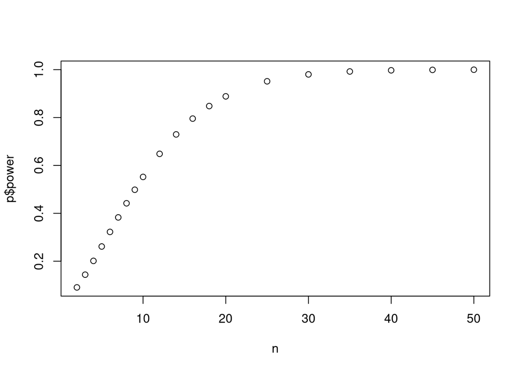

```r
plot(n, p$power)
```

## Tests for Association

Contributions to date: Eriogonum, Calystegia, Phacelia

Example description (making this concrete at the start is useful):

MLH: What is this test used for?

This test is used to determine association between two treatments (or differences). An example could be Harmful Algal Blooms (HABs) as a treatment with Hospital Asthma Cases as an output. Could show the relation between HABs and Asthma Cases going to the hospital. Chi-Square tests for independence/association can only be used between categorical variables.

MLH: What is this test used for?

Answer: There are several tests for association. One of the more popular is the Chi-squared test ($\Chi^2$ test).

A Chi-Squared test is used to determine the association between two categorical variables. The null hypothesis is no association between the two independent variables.

H+M: Strengths of this test = helps measure how a model compares the actual observed data, tells us if two variables are independent of one another.

MLH: Are their assumptions to be concerned about?

The chi-squared test assumes that both variables are are categorical and independent. Assumes that the values are mutually exclusive as well. Data must be frequency data and this test is used when there are larger values. It makes no assumption about the distribution of the data.

The data in the cells should be frequencies, or counts of cases rather than percentages or some other transformation of the data. Categories of the variables are mutually exclusive (one cannot receive the treatment AND not receive the treatment). All observations must be independent. what does independent mean?

### Example 1

Hospital asthema cases and HABs in Florida MLH: Please flesh out example…

#### Creating Data (as a table)

MLH: Describe what’s happening here…

```r
HAB.tab = c(20, 15, 98, 223)
sum(HAB.tab)
```

```
## [1] 356
```

```r
dim(HAB.tab) = c(2,2)
dimnames(HAB.tab) = list(c("Non-HAB", "HAB"), c("No Hospitalizations", "Hospitalizations"))

HAB.tab
```

```
##         No Hospitalizations Hospitalizations
## Non-HAB                  20               98
## HAB                      15              223
```

```r
# HAB.mat = matrix(HAB.tab, nrow=2)
```

```r
table(HAB.tab)
```

```
## HAB.tab
##  15  20  98 223
##   1   1   1   1
```

Describe chisq.test

```r
chisq.test(HAB.tab)
```

```
##
##  Pearson's Chi-squared test with Yates' continuity correction
##
## data:  HAB.tab
## X-squared = 8.9217, df = 1, p-value = 0.002818
```

# Other Types the Might be Important (Marc might discuss if we have time…)

## Count Data

## Multiple Regression

## Two-Way and Mult-Way ANOVAs –

we need data that we don’t have to read.csv…

What is a two-way anova?

### Example #1 –Fertilizer and Crop Yield MLH: Better for Multiway ANOVA

```r
## Looked at Scribbr; entered the crop data to R as a csv##
## Question: How does fertilizer effect crop yield? Testing three different fertilizers##
## command to read the data##
crop.data <- read.csv("crop.data.csv", header)
## command to summarize and make sure everything is working##
summary(crop.data)
str(crop.data)
## use to perform a one.way ANOVA##
## One way ANOVA has one independent independent variable##
## This one way ANOVA models crop yield as a function of the type of fertilizer used##
one.way <- aov(yield~fertilizer,data=crop.data)
## shows what the data compiles into after a one.way##
summary(one.way)
```

```r
## use to perform a two.way ANOVA##
## Two way ANOVA utilizes two independent variables##
## This two way models crop yield as a function of type of fertilizer and planting density##
## Just have to add a plus icon and the extra independent variable##
two.way <- aov(yield ~ fertilizer + density, data = crop.data)
##  shows what the data compiles into after a two.way##
summary(two.way)
## Interaction between variables##
## Used to test whether two variables have an interaction effect##
interaction <- aov(yield ~ fertilizer*density, data = crop.data)
summary(interaction)
```

### Logistic Regression – Multiple Predictors

MLH – The example relies on external data, which adds a step that gets in the way. I suggest we developed example two to keep it simpler…

Research question: Which fertilizer produces the most crop yield? ##Independent variable/predictor: Fertilizer A, Fertilizer B, Fertilizer C ##Dependent variable/response: amount of crop yield

Question: Which fertilizer provides the best crop yield?

It is common for factors to be read as quantitative variables when importing a dataset into R. To avoid this, you can use the read.csv() command to read in the data, specifying within the command whether each of the variables should be quantitative (“numeric”) or categorical (“factor”).

##Use the following code, replacing the path/to/your/file text with the actual path to your file:

```r
# install.packages(c(“ggplot2”, “ggpubr”, “tidyverse”, “broom”, “AICcmodavg”))

# Read Data
# crop.data.csv = file.choose()

crop.data.csv  = "/home/mwl04747/beginnersluck/Stats/EA30_Study_Guide/ANOVA_cropdata.csv"
crop.data <- read.csv(crop.data.csv)

names(crop.data)
crop.data.aov <- aov(Yield ~ Fertilizer, data=crop.data)

summary(crop.data.aov)
```

## Time Series Data

### Autocorrelation

## Count Data

## Mixed Effects Models

# Appendix 1: Soon to be an Alphabetic List of R code and explanation

Please describe in human terms, what are these? and us arg() to show some of the syntax (in human language!)

## Group: Rubus

read.csv()

power.anova.test()

## Group: Eriogonum

lm()

plot()

list()

help.start()

## Group: Calachortus

abline()

str()

help()

## Group: Adenostoma

aov()

summary()

knitr::include_graphics()

## Group Clemitis

dim()

table()

chisq.test()

## Group Phacilia

dimnames()

data.frame()

par()

## Group Marah

c()

predict()

lines()

## Group Calystegia

read.csv() This command is used to read a .csv file that is already in your directory and give it a name so r can read it. It looks like this: data <- read.csv(“input.csv”) Then you can do read(data) to see a preview of the dataset

glm() This command is used to fit generalized linear models, specified by giving a description of the linear predictor and a description of the error distrbution. It looks like this: glm(formula, family = gaussian, data, weights, subset, na.action, start = NULL, etastart, mustart, offset, control = list(…), model = TRUE, method = “glm.fit”, x = FALSE, y = TRUE, singular.ok = TRUE, contrasts = NULL, …) glm.fit(x, y, weights = rep(1, nobs), start = NULL, etastart = NULL, mustart = NULL, offset = rep(0, nobs), family = gaussian(), control = list(), intercept = TRUE, singular.ok = TRUE)

points() This command is used put points at specific coordinates and to be plotted in a plotting structure, a two-column matrix, or a time series. it looks like this: points(x, y = NULL, type = “p”, …)

jitter() This command is used to add a small amount of noise to a numerical vector. It can help the data look a bit clearer on the graph. It looks like this: jitter(x, factor = 1, amount = NULL)

# Appendix 2: Questions to Evaluate our Study Guide

## General questions

1. Is all the rcode described and have comments to help the reader?
2. Is all the data within the documented, no need for external data source links that might break?
3. Is each example described and compelling?
4. Are the results described?
5. Are the models interpreted?

## Quiz Like Questions

Add questions here from our quiz or something that you learned about your topic that you can put in here…

### Linear Regression

1. What is a Linear regression?
2. What is the black diagonal line in Figure 1 called?

```r
(x <- c(1, 2, 3, 4, 5)) # create a vector of x values
```

```
## [1] 1 2 3 4 5
```

```r
(y <- c(1, 2, 1.3, 3.75, 2.25)) #2. create a vector of y-values
```

```
## [1] 1.00 2.00 1.30 3.75 2.25
```

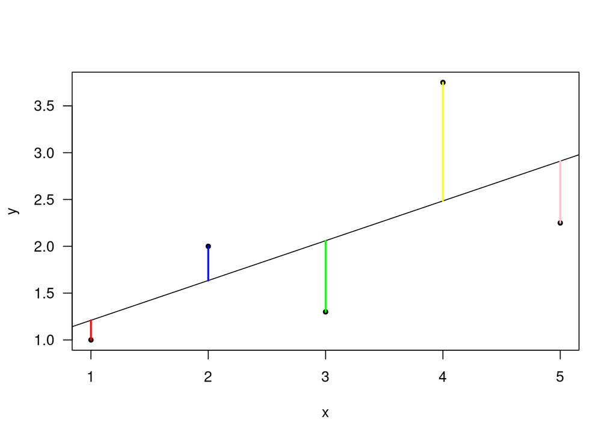

```r
regression.ex.df = data.frame(X=x, Y=y) #make a data frame… (don’t know the function)
par(las=1)
plot(y ~ x, data=regression.ex.df, pch=20)
regression.ex.lm = lm(y~x, data=regression.ex.df)
abline(coef(regression.ex.lm))
regression.ex.df$Residuals = as.vector(resid(regression.ex.lm))
regression.ex.df$Predicted = as.vector(predict(regression.ex.lm, newdata=data.frame(predicted = x)))
regression.ex.df$Color = c("red", "blue", "green", "yellow", "pink")
#lines.mat = mat()
#(xy.coords.ex = xy.coords(rep(x, times=2), c(regression.ex.df$Predicted, c(regression.ex.df$Predicted + regression.ex.df$Residuals))))
#xy.coords.ex[order(xy.coords.ex$x)]
for(i in 1:nrow(regression.ex.df)){
lines(c(regression.ex.df$X[i], regression.ex.df$X[i]), c(regression.ex.df$Predicted[i], c(regression.ex.df$Predicted[i] + regression.ex.df$Residuals[i])), col=regression.ex.df$Color[i], lwd=2)
}
```

```r
#lines(x[1], regression.ex.df$Predicted[1], x, c(regression.ex.df$Predicted[1] + regression.ex.df$Residuals[1]), color=
```

3. Outline the pseudo R code that might be used to generate this graph. In other words, use your words to describe the steps you might need to use to create this graphic (think about how the colored lines might be made and the labels. If you have guesses of the R code syntax, put this in parenthetical statements.

4. The vertical lines on Figure 1 from the points to the regression line represent the errors of prediction. As you can see, the red point is very near the regression line; its error of prediction is small. By contrast, the yellow point is much higher than the regression line and therefore its error of prediction is large. How can the summary() function be used to access the residuals?
5. The summary() function also reports the r2 and p-values for the model. Describe how to interpret these.

### ANOVA

1. What is the difference between a one-way and two-way ANOVA?
2. Given an experiment with a control and three treatments (Treatment) and some measured response (Response) here’s the R code to create the ANOVA object:

Model1.aov <- aov(Response ~ Treatment)

3. How would you generate a summary of the results? How would you report this in a paper?

### Logistic Regression

1. What kind of data is used in a logistic regression?
2. What distribution family is used in the glm() function for logistic regression? Why is this distribution used?

### Tests for Association